# 102625Midterm project 2022 and 2023 cancer dataset analysis Yiwei Gu

#1:

Cancer remains one of the leading causes of morbidity and mortality worldwide, representing a major and growing public health challenge. The global burden of cancer continues to increase, driven by population aging, lifestyle transitions, and environmental exposures. Developing successful preventative programs, allocating resources, and identifying people at highest risk all depend on an understanding of patterns and trends in cancer incidence.

This study utilizes data from the Global Burden of Disease (GBD) project, curated by the Institute for Health Metrics and Evaluation (IHME) at the University of Washington. The GBD database provides comprehensive and standardized estimates of key health indicators—including incidence, prevalence, mortality, and disability-adjusted life years (DALYs)—for more than 200 countries and territories.

In this analysis, datasets from 2022 and 2023 were examined to explore global patterns of cancer incidence. The dataset includes information on multiple cancer types (e.g., breast, lung, colorectal), stratified by sex, country, and year. Each observation represents a specific cancer type’s estimated incidence rate (new cases per 100,000 population), along with its corresponding 95% uncertainty interval (upper and lower bounds). Together, these data allow for comparative and temporal analyses of cancer incidence worldwide.

The goal of this analysis is to explore global patterns of cancer incidence and address the following key questions:

1. In the world, which cancer types are most common?
2. What is the difference in cancer incidence rates between men and women?
3. Which countries show the highest and lowest cancer incidence rates?
4. How have global cancer incidence rates changed from 2022 to 2023?

By addressing these questions, this study aims to provide insights into the global distribution of cancer burden and highlight regional and demographic disparities that may inform future prevention and screening strategies.The results will provide insight into how cancer risks differ by region and sex, and how the global incidence landscape has evolved from 2022 through 2023.

#2:

The dataset analyzed in this project was obtained from the Global Burden of Disease (GBD) Results Tool developed by the Institute for Health Metrics and Evaluation (IHME), available at https://ghdx.healthdata.org/gbd-results-tool. The dataset used in this analysis was downloaded directly from the IHME data portal after registering for an account so that the most recent and standardized global cancer incidence estimates can be accessed. The GBD portal provides datasets separately for each year, the 2022 and 2023 incidence data were downloaded individually and later combined for comparative analysis.

The GBD database provides comprehensive and comparable estimates of disease burden—including incidence, mortality, and disability-adjusted life years (DALYs)—across more than 200 countries and territories.

To acquire the data, the following options were selected:

GBD Estimate: Cause

Measure: Incidence (new cancer cases)

Metric: Rate (per 100,000 population)

Years: 2022, 2023

Sex: Male, Female, Both

Cause: All neoplasms and cancer subtypes

Location: Global and all countries

The resulting CSV file was downloaded directly from the IHME portal and imported into RStudio for analysis using the readr package from the tidyverse library.

```r
library(tidyverse)
```

```r
gbd2022 <- read.csv("~/Library/Mobile Documents/com~apple~CloudDocs/Desktop/dataset2022.csv")

gbd2023 <- read.csv("~/Library/Mobile Documents/com~apple~CloudDocs/Desktop/dataset2023.csv")
```

```r
library(dplyr)

gbd2022_clean <- gbd2022 %>%
  filter(measure == "Incidence", metric == "Rate") %>%
  select(cause, location, sex, year, val, lower, upper)

gbd2023_clean <- gbd2023 %>%
  filter(measure == "Incidence", metric == "Rate") %>%
  select(cause, location, sex, year, val, lower, upper)
```

Merge them into one dataset:

```r
gbd_all <- bind_rows(gbd2022_clean, gbd2023_clean)
```

```r
glimpse(gbd_all)
```

```
Rows: 41,208
Columns: 7
$ cause    <chr> "Malignant skin melanoma", "Malignant skin melanoma", "Malign…
$ location <chr> "Cambodia", "Cambodia", "Cambodia", "Democratic People's Repu…
$ sex      <chr> "Male", "Female", "Both", "Male", "Female", "Both", "Male", "…
$ year     <int> 2022, 2022, 2022, 2022, 2022, 2022, 2022, 2022, 2022, 2022, 2…
$ val      <dbl> 0.16269680, 0.24665877, 0.20568757, 19.19869206, 8.22432753, …
$ lower    <dbl> 0.07363292, 0.10026158, 0.10949805, 10.88535074, 4.06405725, …
$ upper    <dbl> 0.29035749, 0.41869227, 0.30586257, 31.13479689, 13.76693320,…
```

```r
unique(gbd_all$year)
```

```
[1] 2022 2023
```

```r
colSums(is.na(gbd_all))
```

```
   cause location      sex     year      val    lower    upper
       0        0        0        0        0        0        0
```

There are no missing values.

Check duplicates:

```r
dim(gbd2022)
```

```
[1] 20604    10
```

```r
dim(gbd2023)
```

```
[1] 20604    10
```

```r
dim(gbd_all)
```

```
[1] 41208     7
```

Original raw data 2022 (20604x10), 2023 (20604x10), gbd_all: Cleaned + merged dataset (kept only relevant variables) (41208x7)

```r
sum(duplicated(gbd_all))
```

```
[1] 0
```

There are no duplicates after merging the data.

#3:

```r
library(dplyr)
library(knitr)
library(kableExtra)
summary_table <- data.frame(
  Statistic = c("Minimum", "1st Quartile", "Median", "Mean", "3rd Quartile", "Maximum"),
  Value = c(0.0000, 0.8323, 3.0143, 83.2618, 10.4467, 5224.7349)
)

kable(summary_table, caption = "Summary Statistics of Global Cancer Incidence Rates (per 100,000, 2022–2023)") %>%
  kable_styling(full_width = FALSE, position = "center") %>%
  row_spec(0, bold = TRUE, background = "#756bb1", color = "white") %>%   # purple header
  row_spec(1:nrow(summary_table), background = c("#efedf5", "white"))
```

Summary Statistics of Global Cancer Incidence Rates (per 100,000, 2022–2023)

| Statistic | Value |
| --- | --- |
| Minimum | 0.0000 |
| 1st Quartile | 0.8323 |
| Median | 3.0143 |
| Mean | 83.2618 |
| 3rd Quartile | 10.4467 |
| Maximum | 5224.7349 |

The mean incidence rate (83.26 per 100,000) is much higher than the median (3.01), indicating a right-skewed distribution — a few countries or cancer types have extremely high incidence rates. The maximum value (5224.73) is a strong outlier, possibly driven by specific cancer types with small denominators or regional anomalies. Most incidence rates cluster under 10 per 100,000, but a few rare cancers or regions contribute disproportionately high rates.

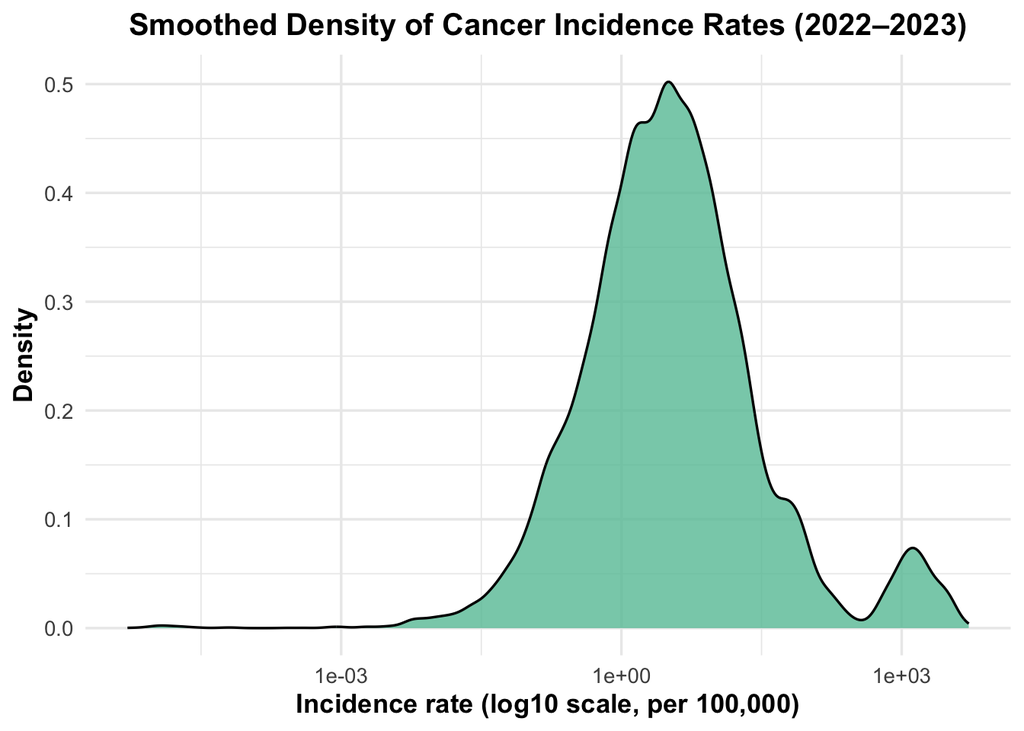

```r
ggplot(gbd_all, aes(x = val)) +
  geom_density(fill = "#66c2a4", alpha = 0.8) +
  scale_x_log10() +
  labs(
    title = "Smoothed Density of Cancer Incidence Rates (2022–2023)",
    x = "Incidence rate (log10 scale, per 100,000)",
    y = "Density"
  ) +
  theme_minimal(base_size = 13) +
  theme(
    plot.title = element_text(face = "bold", size = 15, hjust = 0.5),
    axis.title = element_text(face = "bold", size = 13)
  )
```

Overall, the dataset gbd_all includes 41,208 observations and 7 variables, combining data from 2022 and 2023. Key variables include categorical factors (cause, location, sex) and continuous measures (val, lower, upper, year). The distribution of incidence rates (val) is right-skewed, with most cancers having low rates and a few exhibiting high incidence (e.g., skin, breast, prostate). Data are evenly distributed across sexes and years, and no missing values were detected.

Dataset Characteristics:

```r
library(dplyr)
library(knitr)
library(kableExtra)

exploratory_summary <- tibble(
  Feature = c(
    "Dataset Name",
    "Years Included",
    "Number of Observations (rows)",
    "Number of Variables (columns)",
    "Variables Included",
    "Number of Unique Cancer Types (cause)",
    "Number of Unique Countries/Regions (location)",
    "Sex Categories",
    "Incidence Rate Variable (val)",
    "Uncertainty Interval (lower, upper)",
    "Missing Values",
    "Value Range (val)",
    "Distribution"
  ),
  Description = c(
    "gbd_all",
    paste(unique(gbd_all$year), collapse = ', '),
    nrow(gbd_all),
    ncol(gbd_all),
    paste(names(gbd_all), collapse = ', '),
    length(unique(gbd_all$cause)),
    length(unique(gbd_all$location)),
    paste(unique(gbd_all$sex), collapse = ', '),
    "Age-standardized incidence rate (per 100,000 population)",
    "95% uncertainty interval for incidence estimates",
    ifelse(sum(is.na(gbd_all)) == 0, "No missing values", "Contains missing values"),
    paste0(round(min(gbd_all$val, na.rm = TRUE), 2), " – ",
           round(max(gbd_all$val, na.rm = TRUE), 2)),
    "Right-skewed distribution with few high-incidence cancers"
  )
)

kable(exploratory_summary, caption = "Exploratory Data Summary of Global Cancer Incidence (GBD 2022–2023)") %>%
  kable_styling(
    full_width = FALSE,
    position = "center",
    bootstrap_options = c("striped", "hover", "condensed", "responsive")
  ) %>%
  row_spec(0, bold = TRUE, background = "#756bb1", color = "white") %>%  # purple header
  row_spec(1:nrow(exploratory_summary), background = c("#efedf5", "white"))  # soft purple + white alternation
```

Exploratory Data Summary of Global Cancer Incidence (GBD 2022–2023)

| Feature | Description |
| --- | --- |
| Dataset Name | gbd_all |
| Years Included | 2022, 2023 |
| Number of Observations (rows) | 41208 |
| Number of Variables (columns) | 7 |
| Variables Included | cause, location, sex, year, val, lower, upper |
| Number of Unique Cancer Types (cause) | 35 |
| Number of Unique Countries/Regions (location) | 222 |
| Sex Categories | Male, Female, Both |
| Incidence Rate Variable (val) | Age-standardized incidence rate (per 100,000 population) |
| Uncertainty Interval (lower, upper) | 95% uncertainty interval for incidence estimates |
| Missing Values | No missing values |
| Value Range (val) | 0 – 5224.73 |
| Distribution | Right-skewed distribution with few high-incidence cancers |

The dataset used for this study was obtained from the Global Burden of Disease (GBD) 2022–2023 repository. It contains age-standardized incidence rates (per 100,000 population) for multiple cancer types across different countries, sexes, and years. After cleaning and merging, the combined dataset (gbd_all) included 41,208 observations and 7 variables.

#4:

What is the difference in cancer incidence rates between men and women?

```r
summary_sex <- gbd_all %>%
  filter(sex != "Both") %>%
  group_by(sex) %>%
  summarise(
    mean_incidence = mean(val, na.rm = TRUE),
    median_incidence = median(val, na.rm = TRUE),
    min_incidence = min(val, na.rm = TRUE),
    max_incidence = max(val, na.rm = TRUE)
  )

kable(summary_sex,
      caption = "Summary Statistics of Global Cancer Incidence by Sex (2022–2023)",
      col.names = c("Sex", "Mean", "Median", "Minimum", "Maximum"),
      digits = 2) %>%
  kable_styling(
    full_width = FALSE,
    position = "center",
    bootstrap_options = c("striped", "hover", "condensed", "responsive")
  ) %>%
  row_spec(0, bold = TRUE, background = "#756bb1", color = "white") %>%   # purple header
  row_spec(1:nrow(summary_sex), background = c("#efedf5", "white"))       # alternating lavender and white rows
```

Summary Statistics of Global Cancer Incidence by Sex (2022–2023)

| Sex | Mean | Median | Minimum | Maximum |
| --- | --- | --- | --- | --- |
| Female | 104.12 | 2.68 | 0 | 5224.73 |
| Male | 64.59 | 3.02 | 0 | 4683.12 |

Incidence rates by sex:

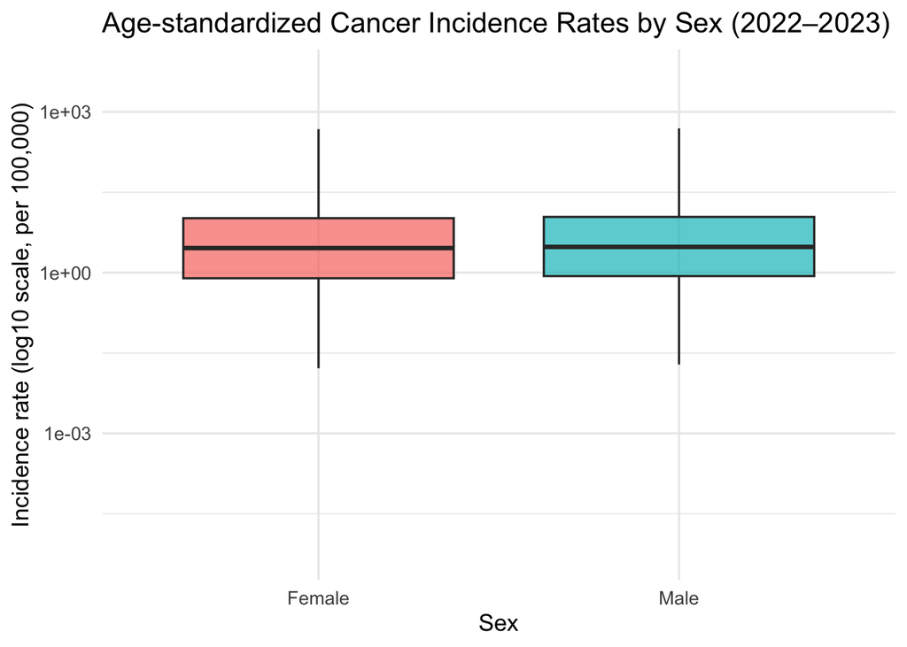

```r
library(ggplot2)
library(dplyr)
gbd_sex <- gbd_all %>%
  filter(sex != "Both")

ggplot(gbd_sex, aes(x = sex, y = val, fill = sex)) +
  geom_boxplot(outlier.shape = NA, alpha = 0.7) +
  scale_y_log10() +
  labs(
    title = "Age-standardized Cancer Incidence Rates by Sex (2022–2023)",
    x = "Sex",
    y = "Incidence rate (log10 scale, per 100,000)"
  ) +
  theme_minimal(base_size = 13) +
  theme(legend.position = "none")
```

1. In the world, which cancer types are most common?(top10)

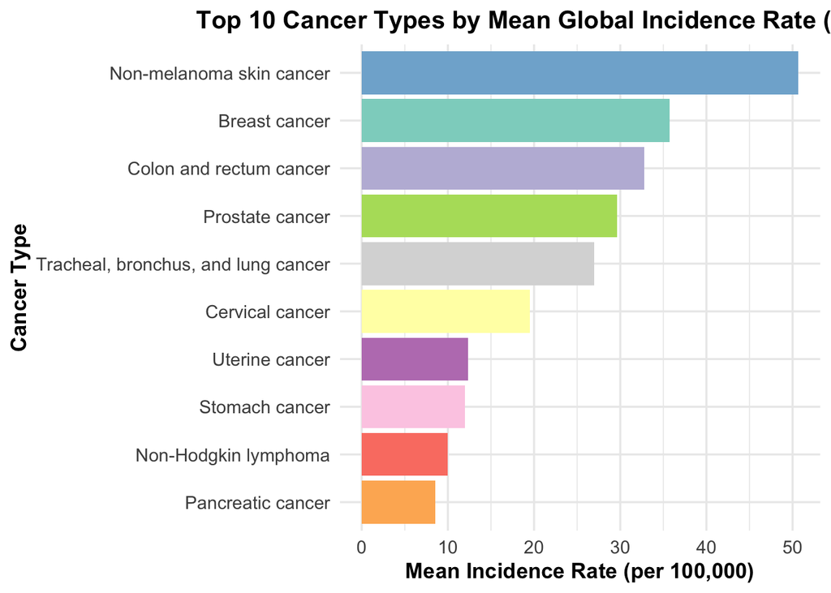

```r
top10_incidence <- gbd_all %>%
  filter(!cause %in% c("Neoplasms", "Other neoplasms")) %>%
  group_by(cause) %>%
  summarise(mean_incidence = mean(val, na.rm = TRUE)) %>%
  arrange(desc(mean_incidence)) %>%
  slice_head(n = 10)

ggplot(top10_incidence, aes(x = reorder(cause, mean_incidence), y = mean_incidence, fill = cause)) +
  geom_col(show.legend = FALSE) +
  coord_flip() +
  labs(
    title = "Top 10 Cancer Types by Mean Global Incidence Rate (2022–2023)",
    x = "Cancer Type",
    y = "Mean Incidence Rate (per 100,000)"
  ) +
  theme_minimal(base_size = 13) +
  theme(
    plot.title = element_text(face = "bold", size = 15, hjust = 0.5),
    axis.title.x = element_text(face = "bold", size = 13),
    axis.title.y = element_text(face = "bold", size = 13),
    axis.text = element_text(size = 11)
  ) +
  scale_fill_brewer(palette = "Set3")
```

This figure shows the top ten cancer types with the highest global mean incidence rates in 2022–2023. Non-melanoma skin cancer and breast cancer dominate worldwide, followed by colorectal, prostate, and lung cancers. The findings highlight the substantial burden of skin and reproductive system cancers on global health.Non-melanoma skin cancer (NMSC) refers to all malignant skin cancers except melanoma.

Breast cancer remains among the top three most frequently diagnosed cancers across nearly all regions, and I would like to see how differently of the incdience rates across the world.

Breast cancer incidence rate as a global level:

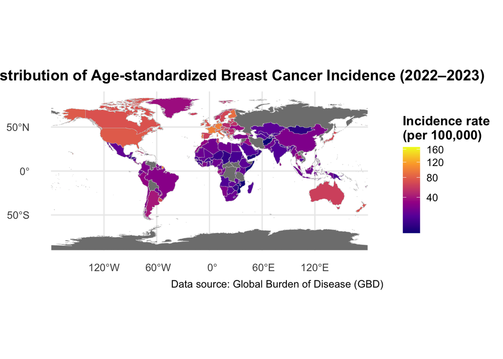

```r
library(rnaturalearth)
library(rnaturalearthdata)
library(sf)
breast_map <- gbd_all %>%
  filter(cause == "Breast cancer") %>%
  group_by(location) %>%
  summarise(mean_incidence = mean(val, na.rm = TRUE))

world <- ne_countries(scale = "medium", returnclass = "sf")

world_breast <- left_join(world, breast_map, by = c("name" = "location"))

ggplot(world_breast) +
  geom_sf(aes(fill = mean_incidence), color = "gray80", size = 0.1) +
  scale_fill_viridis_c(option = "plasma", trans = "sqrt",
                       name = "Incidence rate\n(per 100,000)") +
  labs(
    title = "Global Distribution of Age-standardized Breast Cancer Incidence (2022–2023)",
    caption = "Data source: Global Burden of Disease (GBD)"
  ) +
  theme_minimal(base_size = 13) +
  theme(
    plot.title = element_text(face = "bold", size = 15, hjust = 0.5),
    legend.title = element_text(face = "bold"),
    legend.position = "right"
  )
```

The highest incidence was observed in Western Europe, North America, and Oceania, while much lower rates were seen in sub-Saharan Africa and South Asia. The geographic pattern reflects differences in healthcare access, screening programs, reproductive factors, and lifestyle risk exposures.

Which countries show the highest and lowest cancer incidence rates?

```r
library(knitr)
library(kableExtra)
library(dplyr)
library(ggplot2)

country_rates <- gbd_all %>%
  group_by(location) %>%
  summarise(mean_rate = mean(val, na.rm = TRUE)) %>%
  arrange(desc(mean_rate))

top10 <- country_rates %>% slice(1:10)
bottom10 <- country_rates %>% slice_tail(n = 10)

kable(top10, caption = "Top 10 Countries by Mean Cancer Incidence Rate (2022–2023)") %>%
  kable_styling(full_width = FALSE, position = "center",
                bootstrap_options = c("striped", "hover", "condensed", "responsive")) %>%
  row_spec(0, bold = TRUE, background = "#756bb1", color = "white") %>%
  row_spec(1:nrow(top10), background = c("#efedf5", "white"))
```

Top 10 Countries by Mean Cancer Incidence Rate (2022–2023)

| location | mean_rate |
| --- | --- |
| United States of America | 293.7688 |
| Canada | 262.7463 |
| Austria | 223.7180 |
| Republic of Korea | 221.5325 |
| Japan | 207.8986 |
| Australia | 195.4812 |
| Germany | 191.9716 |
| New Zealand | 189.7859 |
| Principality of Monaco | 189.2698 |
| Croatia | 187.5980 |

```r
kable(bottom10, caption = "Bottom 10 Countries by Mean Cancer Incidence Rate (2022–2023)") %>%
  kable_styling(full_width = FALSE, position = "center",
                bootstrap_options = c("striped", "hover", "condensed", "responsive")) %>%
  row_spec(0, bold = TRUE, background = "#756bb1", color = "white") %>%
  row_spec(1:nrow(bottom10), background = c("#efedf5", "white"))
```

Bottom 10 Countries by Mean Cancer Incidence Rate (2022–2023)

| location | mean_rate |
| --- | --- |
| United Republic of Tanzania | 7.701900 |
| Benin | 7.680018 |
| Burkina Faso | 7.652497 |
| Chad | 7.564000 |
| Republic of the Gambia | 7.353753 |
| Gambia | 7.190149 |
| Niger | 7.039752 |
| Comoros | 6.611494 |
| Somalia | 5.905921 |
| Mozambique | 5.708471 |

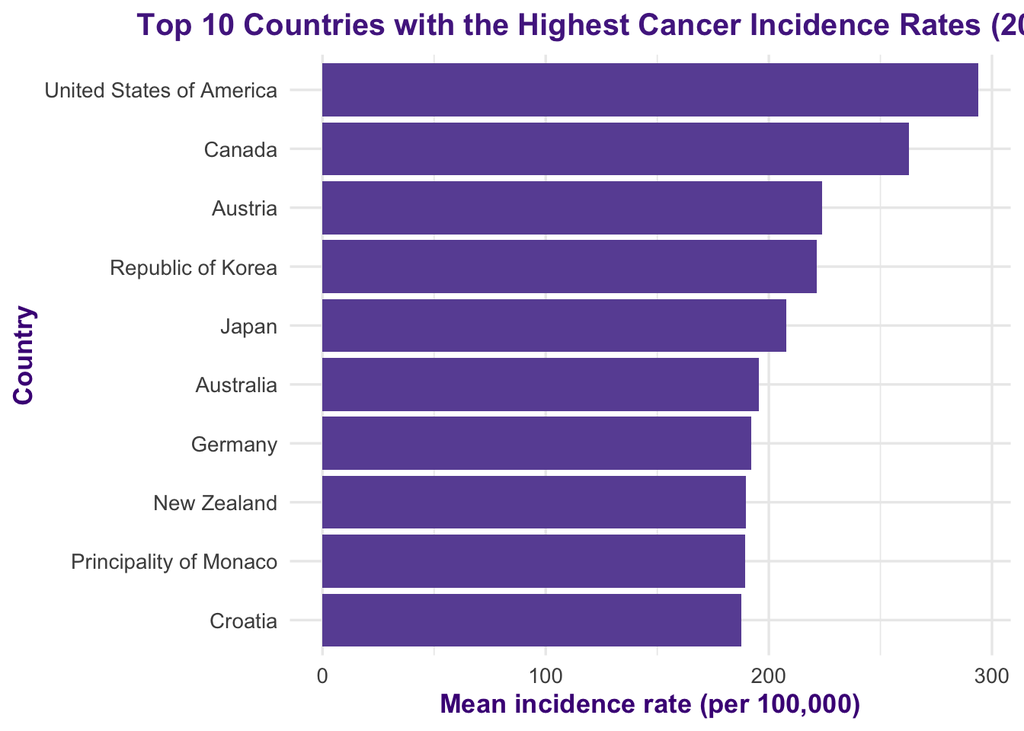

```r
ggplot(top10, aes(x = reorder(location, mean_rate), y = mean_rate)) +
  geom_col(fill = "#6a51a3") +
  coord_flip() +
  labs(
    title = "Top 10 Countries with the Highest Cancer Incidence Rates (2022–2023)",
    x = "Country",
    y = "Mean incidence rate (per 100,000)"
  ) +
  theme_minimal(base_size = 13) +
  theme(
    plot.title = element_text(face = "bold", size = 15, hjust = 0.5, color = "#54278f"),
    axis.title = element_text(face = "bold", color = "#4a1486")
  )
```

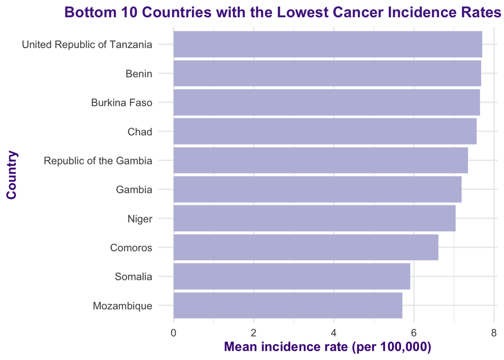

```r
ggplot(bottom10, aes(x = reorder(location, mean_rate), y = mean_rate)) +
  geom_col(fill = "#bcbddc") +
  coord_flip() +
  labs(
    title = "Bottom 10 Countries with the Lowest Cancer Incidence Rates (2022–2023)",
    x = "Country",
    y = "Mean incidence rate (per 100,000)"
  ) +
  theme_minimal(base_size = 13) +
  theme(
    plot.title = element_text(face = "bold", size = 15, hjust = 0.5, color = "#54278f"),
    axis.title = element_text(face = "bold", color = "#4a1486")
  )
```

Highest incidence rates were observed in high-income regions, including the United States (≈294 per 100,000), Canada (≈263), Austria (≈224), Republic of Korea (≈222), and Japan (≈208). Other high-burden countries such as Australia, Germany, and New Zealand also exceeded 180 per 100,000. In contrast, the lowest incidence rates (<10 per 100,000) were found in Sub-Saharan African countries, including Tanzania, Benin, Burkina Faso, Chad, Niger, and Mozambique.

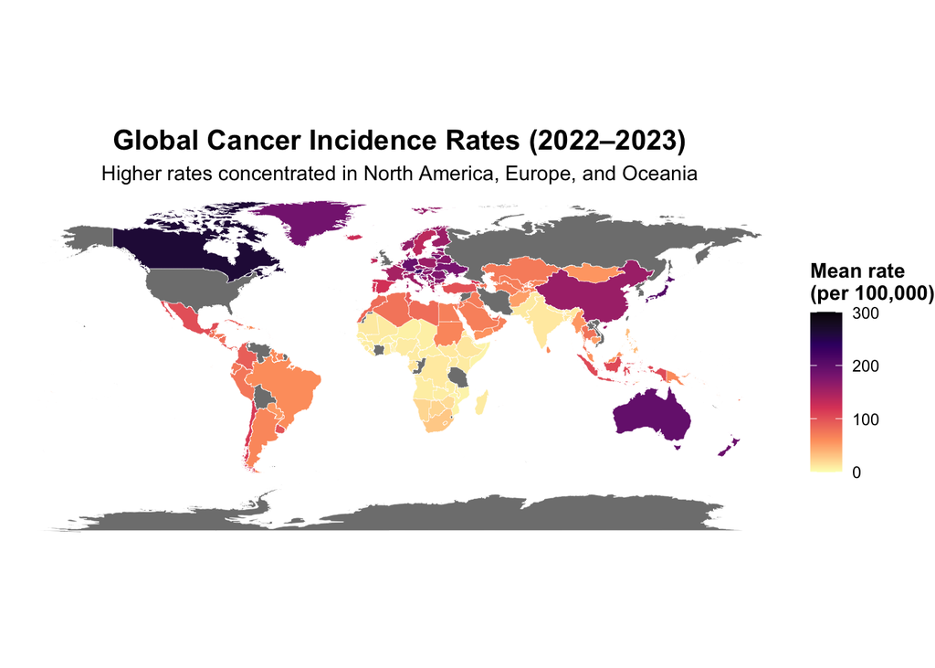

```r
library(ggplot2)
library(maps)
library(dplyr)
library(viridis)
world <- map_data("world")
country_rates$region <- country_rates$location

world_data <- left_join(world, country_rates, by = "region")

ggplot(world_data, aes(long, lat, group = group, fill = mean_rate)) +
  geom_polygon(color = "white", size = 0.1) +
  scale_fill_viridis_c(
    option = "magma",
    direction = -1,
    limits = c(0, 300),
    name = "Mean rate\n(per 100,000)"
  ) +
  labs(
    title = "Global Cancer Incidence Rates (2022–2023)",
    subtitle = "Higher rates concentrated in North America, Europe, and Oceania"
  ) +
  coord_quickmap() +
  theme_void() +
  theme(
    plot.title = element_text(face = "bold", hjust = 0.5, size = 15),
    plot.subtitle = element_text(hjust = 0.5),
    legend.title = element_text(face = "bold")
  )
```

In contrast, low- and middle-income regions across Africa, South Asia, and parts of the Middle East displayed substantially lower reported incidence (<100 per 100,000). This likely reflects limited cancer detection infrastructure, underdiagnosis, and incomplete cancer registry coverage rather than true epidemiological protection.

Overall, the map highlights a global north–south divide, underscoring the intersection of health system capacity, demographic aging, and surveillance quality as key determinants shaping observed cancer burden patterns.

```r
library(ggplot2)

yearly_change <- gbd_all %>%
  group_by(year) %>%
  summarise(mean_rate = mean(val, na.rm = TRUE))


yearly_change
```

```
# A tibble: 2 × 2
   year mean_rate
  <int>     <dbl>
1  2022      82.9
2  2023      83.6
```

[figure not shown]

```r
ggplot(yearly_change, aes(x = factor(year), y = mean_rate, group = 1)) +
  geom_line(color = "#756bb1", linewidth = 1.2) +
  geom_point(size = 5, color = "#54278f") +
  geom_text(aes(label = round(mean_rate, 1)),
            vjust = -1, size = 5, fontface = "bold", color = "black") +

  annotate("text", x = 1.5, y = max(yearly_change$mean_rate) + 2,
           label = paste0("+", round(diff(yearly_change$mean_rate), 1),
                          " per 100,000 (+",
                          round((diff(yearly_change$mean_rate) / yearly_change$mean_rate[1]) * 100, 2),
                          "%)"),
           color = "#54278f", size = 5, fontface = "italic") +
  labs(
    title = "Global Mean Cancer Incidence Rates (2022 vs 2023)",
    subtitle = "Minimal year-to-year change (+0.8 per 100 000, ≈ +1%)",
    x = "Year", y = "Mean incidence rate (per 100 000)"
  ) +
  ylim(min(yearly_change$mean_rate) - 2, max(yearly_change$mean_rate) + 6) +
  theme_minimal(base_size = 14) +
  theme(
    plot.title = element_text(face = "bold", hjust = 0.5),
    plot.subtitle = element_text(hjust = 0.5, color = "gray40"),
    axis.title = element_text(face = "bold")
  )
```

#5: